# Assignment 5

## 2.2 Gapminder after removing Oceania

Here I filter out Oceania and drop all unused levels.

```r
gapdrop <- gapminder %>%
  filter(continent != "Oceania") %>%
  droplevels()
```

Oceania is no longer represented in the boxplot.

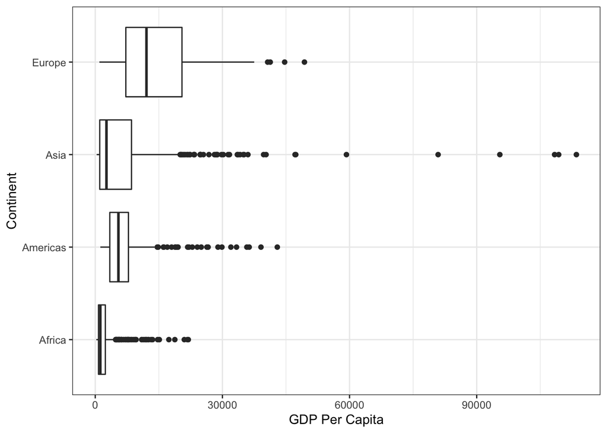

```r
gapdrop %>%
  ggplot() +
  geom_boxplot(aes(continent, gdpPercap)) +
  coord_flip()+
  theme_bw() +
  xlab("Continent")+
  ylab("GDP Per Capita")
```

```r
gapdrop$continent %>%
  nlevels()
```

```
## [1] 4
```

```r
nrow(gapdrop)
```

```
## [1] 1680
```

Now there are only 4 continent levels and 1680 rows in total.

Here I rearrange the continent levels by increasing spread (standard deviation) in GDP per capita.

[figure not shown]

```r
gapdrop %>%
  ggplot() +
  geom_boxplot(aes(fct_reorder(continent, gdpPercap, sd), gdpPercap)) +
  coord_flip()+
  theme_bw() +
  xlab("Continent")+
  ylab("GDP Per Capita") +
  labs(title = "Countries that start with B")
```

# 3 File I/O

```r
library(here)
countries <- levels(gapminder$country) %>%
  tidyselect::vars_select(starts_with("B"))

 gapminder %>%
  filter(country %in% countries) %>%
  group_by(continent) %>%
   write.csv(here("Bcountries.csv"))
```

Here I filter the gapminder dataset to include only countries that start with the letter B (i.e. Brazil, Bulgaria, etc) and save it to a csv.

```r
bcountries <- read.csv(here("Bcountries.csv")) %>%
  select(-X)
```

After reading the csv back into R, there is a new column named ‘X’ that contains the row index number. This must have been created when I wrote the data to csv. It is useless in R, so I remove it here.

Here’s a plot of the populations in the new dataset. I ordered the continents by their mean population, but it didn’t look good, so I then reversed the order.

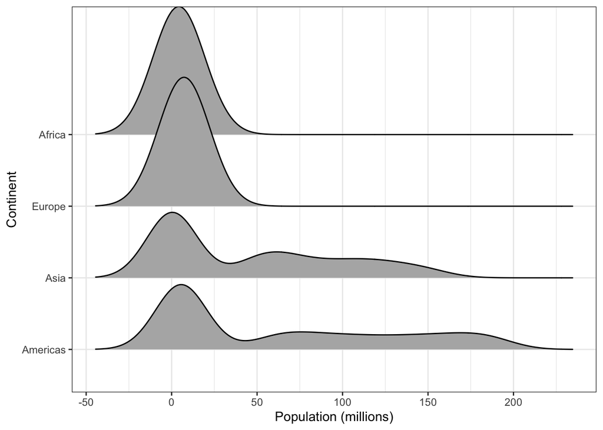

```r
ggplot(bcountries) +
  geom_density_ridges(aes(pop/1000000,fct_rev(fct_reorder(continent, pop, mean)))) +
  theme_bw() +
  scale_x_continuous(labels = comma_format()) +
  xlab("Population (millions)") +
  ylab("Continent")
```

# 4 Visualization design

Old plot:

```r
p1 <- gapminder %>%
ggplot(aes(x = pop, y = lifeExp, color = country, alpha = year)) +
  scale_x_continuous(trans= "log10") +
  facet_grid(gapminder$continent) +
  geom_point() +
  theme(legend.position = "none")
```

Revised plot:

```r
p2 <- gapminder %>%
  group_by(country, continent) %>%
  summarize(pop = mean(pop), lifeExp = mean(lifeExp)) %>%
  ungroup() %>%
ggplot(aes(x = pop/1000000, y = lifeExp, color = continent)) +
  scale_x_log10(labels = comma_format()) +
  labs(title = "1952-2007",
       x = "Average Population (millions)",
       y = "Average Life Expectancy (years)",
       color = "Continent") +
  geom_point(alpha = 0.7, size = 0.7) +
  geom_smooth(method = "lm", se = F) +
  theme_bw() +
  theme(legend.key.width = unit(0.05, "cm"),
        legend.text = element_text(size = 10))
```

Used grid.arrange() to create side-by-side comparison:

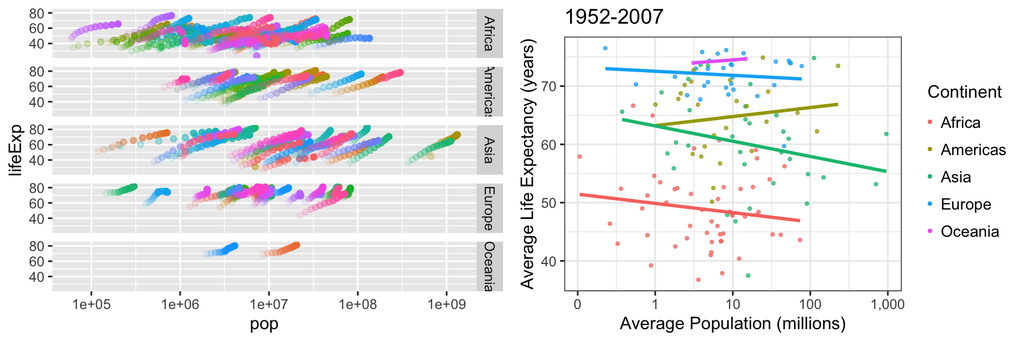

```r
grid.arrange(p1, p2, nrow = 1)
```

On the left is a plot I made in Assignment 2. Even though I think all the dots look like fireworks, it is not very informative. The labels do not explain what you’re looking at. Using alpha to represent years is pobably not a good idea. There were too many countries to represent in a legend, so I just removed it. That might be ok if this was an interactive plotly graph, but it is not good for a normal ggplot.

On the right is a revised version of this plot.

Improvements

- Removed gray background
- Reduced number of points by averaging over years
- Added better axis, title, and legend labels
- Removed faceting for better intercontinental comparison
- Decreased size and alpha of points to icrease clarity
- Added linear trend lines to highlight possible relationships/interactions

# 5 Writing Figures to File

```r
p <- gapdrop %>%
  ggplot() +
  geom_boxplot(aes(fct_reorder(continent, gdpPercap, sd), gdpPercap)) +
  coord_flip()+
  theme_bw() +
  xlab("Continent")+
  ylab("GDP Per Capita") +
  labs(title = "Countries that start with B")

ggsave("bcountries_plot.png",
       device = "png",
       plot = p,
       path = here())
```

I don’t know how to control the size of this figure!

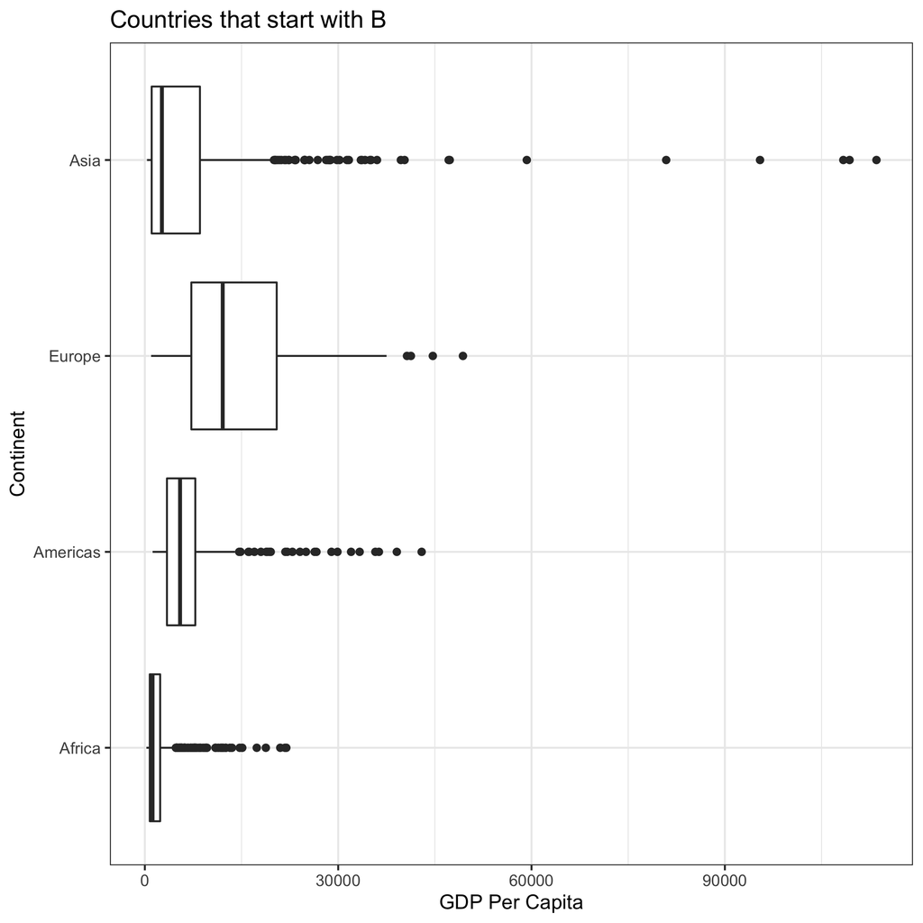